# **Student Exam Performance**

In life certain attributes and traits of people often contributes to societies unconscious bias of them. This is particularly present in the schooling system, where a students chance success is often pre-determined simply based on who they are. It's this type of problem that really gets you thinking, can we actually predict a student's success only based on their attributes?

In this project I will be analyzing a dataset of different students' performance on three types of exams. The data was collected in 2017 on a group of grade 6 students across a schooling district. The area of this district is unspecified. This data set can be found on kaggle.com and includes over 1000 data entries. Each entry in the data set is 1 student and contains both categorical and quantitative data. The categorical data includes information about their gender, race, parent level of schooling, lunch, and test preparation. Where the quantitative data covers their scores on math, reading, and writing exams.

We are going to use this data to analyze how these different variables may effect students test scores. This data analysis works to evaluate the validity of bias based on student attributes, and explore what actions parents can be taking to increase their child's success. Note that for this dataset race/ethnicity is referred to as groupings, this means we will not be naming races or ethnicity in our report.

# **What Are We Testing?**

This project's overall purpose is to dive deeper into the effects that a student's background and attributes has on their average exam scores. We will explore this overall theme through a series of smaller questions shown below:

1. What is the average exam scores of students given their race/ethnicity? What group has the highest?
2. What is the most common combination of attributes for a student, how many unique students exist in this dataset?
3. Does a student's parents completing post-secondary education give them an advantage when taking exams?
4. Is a student's lunch level influenced by their parents education level?
5. Are we really able to predict a student's average exam score given their attributes?
6. What attribute gives a student the most advantage? What about the least?

# **Data Exploration**

### **Initializing the Data Set**

*To be begin our analysis we will first import all the tools we need to work with the data. We will also initialize the dataset as a pandas data frame with our file's path.*

```python
import matplotlib
#matplotlib.use('Agg')
from datascience import *
import seaborn as sns
%matplotlib inline
import matplotlib.pyplot as plt
from mpl_toolkits.mplot3d import Axes3D
import numpy as np
import math
import scipy.stats as stats
from scipy.optimize import minimize
import pandas as pd
plt.style.use('fivethirtyeight')
pd.set_option('display.max_columns', None)
pd.set_option('display.max_colwidth', None)
```

For the sake of my reporting of the data I will be setting a numpy seed so all randomization will be the same not matter how many times it is run.

```python
np.random.seed(2204)
```

```python
students = pd.read_csv('study_performance.csv')
```

Now that our data frame is initialized we can view some information about it using the .info() function

```python
students.info
```

```
<bound method DataFrame.info of      gender race_ethnicity parental_level_of_education         lunch  \
0    female        group B           bachelor's degree      standard
1    female        group C                some college      standard
2    female        group B             master's degree      standard
3      male        group A          associate's degree  free/reduced
4      male        group C                some college      standard
..      ...            ...                         ...           ...
995  female        group E             master's degree      standard
996    male        group C                 high school  free/reduced
997  female        group C                 high school  free/reduced
998  female        group D                some college      standard
999  female        group D                some college  free/reduced

    test_preparation_course  math_score  reading_score  writing_score
0                      none          72             72             74
1                 completed          69             90             88
2                      none          90             95             93
3                      none          47             57             44
4                      none          76             78             75
..                      ...         ...            ...            ...
995               completed          88             99             95
996                    none          62             55             55
997               completed          59             71             65
998               completed          68             78             77
999                    none          77             86             86

[1000 rows x 8 columns]>
```

This shows us a few of the starting and ending rows from the table, as well as the table dimensions. Our data set is 1000 entries, each with columns of data.

Since our main focus of this data set is to look at students average exam scores, we must first calculate the students averages and add them to the data frame.

```python
total = students['math_score'] + students['reading_score'] + students['writing_score']
average = total / 3
students['average'] = average
students_select = students[['gender', 'race_ethnicity', 'parental_level_of_education', 'lunch', 'test_preparation_course','average']]
students_select
```

|  | gender | race_ethnicity | parental_level_of_education | lunch | test_preparation_course | average |
| --- | --- | --- | --- | --- | --- | --- |
| 0 | female | group B | bachelor's degree | standard | none | 72.666667 |
| 1 | female | group C | some college | standard | completed | 82.333333 |
| 2 | female | group B | master's degree | standard | none | 92.666667 |
| 3 | male | group A | associate's degree | free/reduced | none | 49.333333 |
| 4 | male | group C | some college | standard | none | 76.333333 |
| ... | ... | ... | ... | ... | ... | ... |
| 995 | female | group E | master's degree | standard | completed | 94.000000 |
| 996 | male | group C | high school | free/reduced | none | 57.333333 |
| 997 | female | group C | high school | free/reduced | completed | 65.000000 |
| 998 | female | group D | some college | standard | completed | 74.333333 |
| 999 | female | group D | some college | free/reduced | none | 83.000000 |

1000 rows × 6 columns

Now we have a focus only on the data that is relevant to the questions we have established.

With the data frame initialized, we can start to explore some of the distributions of our data. I am going to generate a few pi charts to show the distributions of our categorical data, and then a histogram to show the distribution of our numerical data.

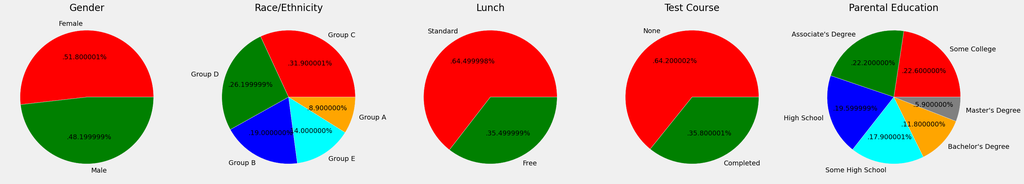

```python
plt.rcParams['figure.figsize'] = (30, 8)

plt.subplot(1, 5, 1)
size = students_select['gender'].value_counts()
labels = 'Female', 'Male'
color = ['red','green']

plt.pie(size, colors = color, labels = labels,autopct = '.%2f%%')
plt.title('Gender', fontsize = 20)
plt.axis('off')

plt.subplot(1, 5, 2)
size = students_select['race_ethnicity'].value_counts()
labels = 'Group C', 'Group D','Group B','Group E','Group A'
color = ['red', 'green', 'blue', 'cyan','orange']

plt.pie(size, colors = color,labels = labels,autopct = '.%2f%%')
plt.title('Race/Ethnicity', fontsize = 20)
plt.axis('off')

plt.subplot(1, 5, 3)
size = students_select['lunch'].value_counts()
labels = 'Standard', 'Free'
color = ['red','green']

plt.pie(size, colors = color,labels = labels,autopct = '.%2f%%')
plt.title('Lunch', fontsize = 20)
plt.axis('off')

plt.subplot(1, 5, 4)
size = students_select['test_preparation_course'].value_counts()
labels = 'None', 'Completed'
color = ['red','green']

plt.pie(size, colors = color,labels = labels,autopct = '.%2f%%')
plt.title('Test Course', fontsize = 20)
plt.axis('off')

plt.subplot(1, 5, 5)
size = students_select['parental_level_of_education'].value_counts()
labels = 'Some College', "Associate's Degree",'High School','Some High School',"Bachelor's Degree","Master's Degree"
color = ['red', 'green', 'blue', 'cyan','orange','grey']

plt.pie(size, colors = color,labels = labels,autopct = '.%2f%%')
plt.title('Parental Education', fontsize = 20)
plt.axis('off')

plt.tight_layout()
plt.grid()

plt.show()
```

We made these pie charts using the subplot and pie features. Our code first initializes the data we are looking at with the size, labels, colors. Then we use plt.pie to use our data and convert it to a visual, we are also putting labels on the data, and quantities inside of the slices. (labels,autopct = '.%2f%%' simply works to format the numbers we generate as percents)

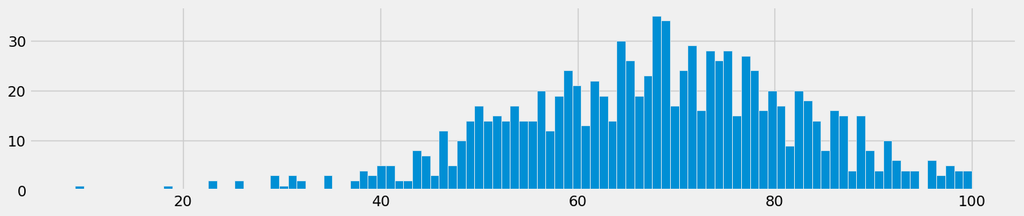

```python
fig, ax = plt.subplots(figsize=(15,3))
ax.hist(students_select['average'], bins = 101)
plt.show()
```

These series of visuals help us to get a better understanding of what our dataset looks like. Our group of 1000 students is majority female (51.8%). Most of the students receive standard lunch instead of free. Most students do not complete test preparations. For race/ethnicity we see that the largest population is of Group C, where the minority is Group A. For education we see that the largest group has parents with Some College completed, where the least have parents with a Master's Degree.

The histogram shows us that the average exam score of a student likely exists around 65-75%, we can say this because the curve of our data is centered near 70 and tails to the left. This is not quite a normal distribution but there is a clear bell curve shape.

# **Averages By Race/Ethnicity**

Now with our better understanding of the data we can dive into our first question: **What is the average exam scores of students given their race/ethnicity? What group has the highest?**

To do this we will isolate the race_ethnicity column and the average column and use them to calculate the averages per grouping.

*Before we start calculating the average lets take a look at our distribution again:*

```python
dist = students_select.groupby('race_ethnicity').size()
print(dist)
```

```
race_ethnicity
group A     89
group B    190
group C    319
group D    262
group E    140
dtype: int64
```

*This shows the same thing we saw in the pie chart but slightly more detailed. It also helps us to interpret the averages we calculate, as the averages for group C and D may be more accurate than that of Group A due to their size.*

Now lets look at the groups of race/ethnicity compared to their test scores. To do this I am going to generate the same exam score histogram from before, but this time it will be color coded by grouping.

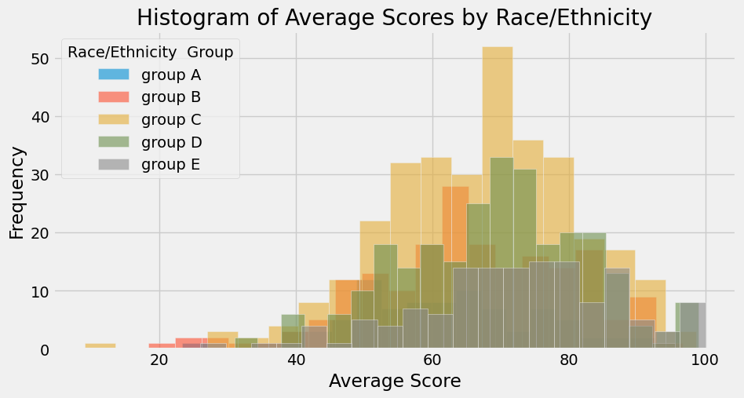

```python
groups = students_select.groupby('race_ethnicity')
plt.figure(figsize=(10, 5))
for name, group in groups:
    plt.hist(group['average'], bins=20, alpha=0.6, label=name)
plt.title('Histogram of Average Scores by Race/Ethnicity')
plt.xlabel('Average Score')
plt.ylabel('Frequency')
plt.legend(title='Race/Ethnicity  Group')
plt.show()
```

We generated this plot using an edited version of the .hist function. We grouped the data and then generated a histogram for each group, then put them all in 1 plot placed on top of each other. From this method we can see that our group E distribution is based slightly to the right, where our group B distribution may be based slightly to the left. From this we can predict that group E will have a higher average than group B. To test this we will now calculate the averages for each group:

```python
means_table = students_select.groupby('race_ethnicity')['average'].mean().reset_index()
means_table.columns = ['race_ethnicity', 'average']
print(means_table)
```

```
  race_ethnicity    average
0        group A  62.992509
1        group B  65.468421
2        group C  67.131661
3        group D  69.179389
4        group E  72.752381
```

This is the average of the average exam scores for each group of race/ethnicity. We can see that our prediction of group E having a higher based distribution is true as it had the highest average.

### **Recap**

Lets look back at what we discovered in this section.

In this section of the project we explored further into the race/ethnicity portion of the dataset. We generated visuals that helped us to better understand how the data was distributed. Then we found the averages from each group of race/ethnicity which brings us the answer to our first question. What is the average exam scores of students given their race/ethnicity? What group has the highest? **Group E has the highest average exam scores.**

# **Data Variation**

Now we have seen a little bit about how the data is distributed and how some trends exist withing different data groupings. This raises the question, how unique are the students? When I say this I mean how many students exist in our dataset that have the exact same lineup of attributes, or maybe share 80% of their attributes with another student. This is relevant moving forward when we attempt to predict students scores because more variation means more data to work with. This section will focus on our question: **What is the most common combination of attributes for a student, how many unique students exist in this dataset?**

Not including our students exam scores, they have 5 unique columns for attribute information. Given all the possible inputs for each attribute there is 240 unique combinations of inputs. This means that statistically there must be some number of 'same-attribute' students within the dataset. To start we want to create a new table that focuses only on our attributes.

```python
students_dupe = students[['gender', 'race_ethnicity', 'parental_level_of_education', 'lunch', 'test_preparation_course']]
students_dupe
```

|  | gender | race_ethnicity | parental_level_of_education | lunch | test_preparation_course |
| --- | --- | --- | --- | --- | --- |
| 0 | female | group B | bachelor's degree | standard | none |
| 1 | female | group C | some college | standard | completed |
| 2 | female | group B | master's degree | standard | none |
| 3 | male | group A | associate's degree | free/reduced | none |
| 4 | male | group C | some college | standard | none |
| ... | ... | ... | ... | ... | ... |
| 995 | female | group E | master's degree | standard | completed |
| 996 | male | group C | high school | free/reduced | none |
| 997 | female | group C | high school | free/reduced | completed |
| 998 | female | group D | some college | standard | completed |
| 999 | female | group D | some college | free/reduced | none |

1000 rows × 5 columns

This data frame now has only our categorical data. To could the unique rows, we will identify all of the duplicate rows. After identifying them we will group them similar to what we did with the race/ethnicity. From that grouping we will be able to see how many of each duplicate row exists.

```python
duplicates = students_dupe[students_dupe.duplicated(keep=False)]
duplicate_counts = duplicates.groupby(duplicates.columns.tolist()).size().reset_index()
duplicate_counts.columns = duplicates.columns.tolist() + ['count']
duplicate_counts_sorted = duplicate_counts.sort_values(by='count', ascending=False)
with pd.option_context('display.width', 1000):
    print("Duplicate Rows Count:")
    print(duplicate_counts_sorted)

    print("Duplicate Rows:")
    print(duplicates)
```

```
Duplicate Rows Count:
     gender race_ethnicity parental_level_of_education         lunch test_preparation_course  count
36   female        group C          associate's degree      standard                    none     21
50   female        group C                some college      standard                    none     19
134    male        group C                 high school      standard                    none     17
44   female        group C                 high school      standard                    none     15
35   female        group C          associate's degree      standard               completed     15
..      ...            ...                         ...           ...                     ...    ...
45   female        group C             master's degree  free/reduced                    none      2
43   female        group C                 high school      standard               completed      2
156    male        group D                 high school      standard               completed      2
27   female        group B                some college      standard               completed      2
91   female        group E                some college  free/reduced                    none      2

[182 rows x 6 columns]
Duplicate Rows:
     gender race_ethnicity parental_level_of_education         lunch test_preparation_course
0    female        group B           bachelor's degree      standard                    none
1    female        group C                some college      standard               completed
2    female        group B             master's degree      standard                    none
3      male        group A          associate's degree  free/reduced                    none
4      male        group C                some college      standard                    none
..      ...            ...                         ...           ...                     ...
995  female        group E             master's degree      standard               completed
996    male        group C                 high school  free/reduced                    none
997  female        group C                 high school  free/reduced               completed
998  female        group D                some college      standard               completed
999  female        group D                some college  free/reduced                    none

[971 rows x 5 columns]
```

We used the duplicated function to find the duplicate rows within the data frame. Then it grouped these duplicate rows by attributes. The grouped columns are then sorted so that the outputted data frame shows the most common combination of attributes at the top, and the least common at the bottom

From our output we can see that the most common student is one who is female, from race group C, parent's have an associate's degree, they eat standard lunch, and they do not complete their test preparations.

If we take a look at the distributions of our data groups again we can see that this aligns with the distributions of data within the attributes.

We can also do some math with the tables to see how many unique groups we have. Since our duplicate grouping is 182 rows we know that is 182 unique entries. Our duplicates table is 971 rows, this means 29 rows exist with no duplicates making them unique and not included in the duplicates grouping. 182+29=211 Our dataset has 211 unique entries, meaning we are only missing 29 possible combinations of attributes.

For the sake of our conclusion I am also going to find the number of unique average exam scores using this code:

```python
unique_count = students_select['average'].nunique()
print("Number of unique averages:", unique_count)
```

```
Number of unique averages: 194
```

### **Recap**

In this section we explored how unique our data is. We first extracted our duplicate rows within the data frame and grouped them all together. This method gave us the most popular set of attributes, of which showed up 21 times! We then did some small math to find that out of 240 possible unique entries, our dataset accounts for 211 of them. This means that out of 1000 data entries, there are only 211 unique values, this may cause some issues in the future with prediction as our data does not have much variety. Overall we can answer our second question. What is the most common combination of attributes for a student, how many unique students exist in this dataset? **Our most common student is one who is female, from race group C, parent's have an associate's degree, they eat standard lunch, and they do not complete their test preparations. We have 211 unique data points in our 1000 point dataset.**

# **Hypothesis Testing #1 (Education vs. Average)**

To this point in the project we have been exploring the data and drawing conclusions using very typical practices. In this section we will explore a hypothesis we presented in one of our questions and use A/B testing to reach a conclusion.

A null hypothesis can be described as the hypothesis that assumes we have no connection. The alternative hypothesis is the hypothesis that we are looking to prove, and it contradicts the null hypothesis. Here are our null and alternative hypotheses:

**Null Hypothesis:** In the population, the distribution of average exam scores of students is the same for students with parents who have completed up to a highschool diploma and those whose parents have completed some capacity of post-secondary education.

**Alternative Hypothesis:** In the population, the average exam scores of students whose parents have completed post-secondary education will be higher, on average, than the students whose parents have only completed up to a highschool diploma.

### **Data Prep**

We need to first prep our data before conducting A/B testing.

To conduct A/B testing, we want no more than 2 variations of our variable. This means we will group some of our data together, to make the data more manageable. These groups will be: highschool_and_below, college_and_above.

```python
students_edit = students_select.copy()

replacements = {
    'some high school': 'highschool_and_below',
    'high school': 'highschool_and_below',
    'some college': 'highschool_and_below',
    "associate's degree": 'college_and_above',
    "bachelor's degree": 'college_and_above',
    "master's degree": 'college_and_above'
}

students_edit['parental_level_of_education'] =students_edit['parental_level_of_education'].map(replacements).fillna(students_edit['parental_level_of_education'])
students_simple = students_edit[['parental_level_of_education', 'average']]
with pd.option_context('display.width', 1000):
    print(students_simple)
```

```
    parental_level_of_education    average
0             college_and_above  72.666667
1          highschool_and_below  82.333333
2             college_and_above  92.666667
3             college_and_above  49.333333
4          highschool_and_below  76.333333
..                          ...        ...
995           college_and_above  94.000000
996        highschool_and_below  57.333333
997        highschool_and_below  65.000000
998        highschool_and_below  74.333333
999        highschool_and_below  83.000000

[1000 rows x 2 columns]
```

This table now has parental_level_of_education as 2 groups. We also don't need any of our other categorical variables for this test so I have removed them to make it easier to read.

### **Test Statistic**

*Now that we have established our null and prepared our data, we can do A/B testing to accept or reject this hypothesis.*

Since our null hypothesis is comparing exams averages based on parental levels of schooling, we will compare the difference of the averages for these groups, we can do this using A/B testing. This is where we test the difference of means between the 2 groups(college_and_above and highschool_and_below).

```python
means_table = students_simple.groupby('parental_level_of_education')['average'].mean().reset_index()
means_table.columns = ['parental_level_of_education', 'average']
print(means_table)
```

```
  parental_level_of_education    average
0           college_and_above  70.861320
1        highschool_and_below  65.718802
```

```python
means = means_table
observed_differenceAB = round(means.iloc[1,1] - means.iloc[0,1], 2)
print("Observed difference between 'college_and_above' and 'highschool_and_below':", observed_differenceAB)
```

```
Observed difference between 'college_and_above' and 'highschool_and_below': -5.14
```

Here we can look at the average of average exams scores from each group. Remember the average is taken from the students 3 exams scores. The negative difference shows that students in the college_and_above group have higher average test scores than those in highschool_and_below. Meaning college_and_above scores 5.14 test points higher on average than highschool and below. But now we need to test if this is just a coincidence or a correlation.

We can generalize this equation for repeated use, it will take 2 inputs and output the difference of means.

```python
def difference_of_means(table, group_label):
    reduced = table[['average', group_label]]
    means_table = reduced.groupby(group_label)['average'].mean()
    return means_table.iloc[1] - means_table.iloc[0]

# Call the function with your DataFrame and group label
observed_differenceAB = round(difference_of_means(students_simple, 'parental_level_of_education'), 2)
print("Observed difference between 'college_and_above' and 'highschool_and_below':", observed_differenceAB)
```

```
Observed difference between 'college_and_above' and 'highschool_and_below': -5.14
```

This difference of means matches that of which we calculated previously.

### **Predicting the Test Statistic Under the Null**

*To see how the test statistic will vary under the null hypothesis we need to simulate the statistic. To do this we will conduct random permutation.*

We will now simulate values of the test statistic within our data. This is done by shuffling the labels on the data, meaning we will mix up what data has the label college_and_above and highschool_and_below. The number of students in each group will not change, but the values will. This process is called Random Permutation.

```python
students_shuffled = students_simple.copy()

shuffled_labels = students_shuffled['parental_level_of_education'].sample(frac=1, replace=False).reset_index(drop=True)

students_shuffled['Shuffled Label'] = shuffled_labels

print(students_shuffled)
```

```
    parental_level_of_education    average        Shuffled Label
0             college_and_above  72.666667  highschool_and_below
1          highschool_and_below  82.333333  highschool_and_below
2             college_and_above  92.666667     college_and_above
3             college_and_above  49.333333  highschool_and_below
4          highschool_and_below  76.333333  highschool_and_below
..                          ...        ...                   ...
995           college_and_above  94.000000  highschool_and_below
996        highschool_and_below  57.333333     college_and_above
997        highschool_and_below  65.000000  highschool_and_below
998        highschool_and_below  74.333333  highschool_and_below
999        highschool_and_below  83.000000  highschool_and_below

[1000 rows x 3 columns]
```

Here we have generated a table that has the original label under parental_level_of_education, the original average under average, and the new label under Shuffled Label. We can now calculate the new group means with the new labels and compare it to that of the original.

```python
shuffled_means_table = students_shuffled.groupby('Shuffled Label')['average'].mean().reset_index()
shuffled_means_table.columns = ['Shuffled Label', 'average']
print(shuffled_means_table)
```

```
         Shuffled Label    average
0     college_and_above  67.363409
1  highschool_and_below  68.041043
```

```python
print(round(difference_of_means(students_shuffled, 'Shuffled Label'), 2))
```

```
0.68
```

```python
difference_of_means(students_shuffled, 'parental_level_of_education')
```

```
-5.1425179699109123
```

The difference of means with the newly shuffled groups is significantly smaller than that of the original data set. However to ensure that this is not just by chance from 1 random shuffle, we will create a code that will repeat this process many times for a more accurate result. To do that we must create a function that combines the code we just used for the shuffling process.

```python
def one_simulated_difference_of_means():

    # Shuffle the 'parental_level_of_education' column without replacement
    shuffled_labels = students_simple['parental_level_of_education'].sample(frac=1, replace=False).reset_index(drop=True)

    # Create a DataFrame with the shuffled labels and 'average' column
    shuffled_table = pd.DataFrame({'average': students_simple['average'], 'Shuffled Label': shuffled_labels})

    # Calculate the difference of means using the shuffled table
    return difference_of_means(shuffled_table, 'Shuffled Label')
```

```python
one_simulated_difference_of_means()
```

```
-1.3198720595165128
```

With this code we can now continue with a larger scale random permutation test.

### **Permutation Test and Conclusion**

Now that we have established how we will simulate the test statistic, we will repeat this many times to collect a more accurate sample.

```python
differences = []

repetitions = 5000
for i in range(repetitions):
    new_difference = one_simulated_difference_of_means()
    differences.append(new_difference)

differences = np.array(differences)
```

Here we are conducting the previous test 5000 times, and we will look at the distribution of these test results.

```
Observed Difference: -5.14
```

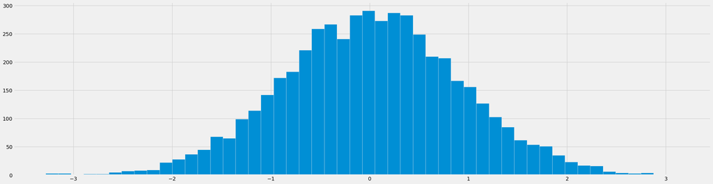

```python
plt.hist(differences, bins=50)
print('Observed Difference:', observed_differenceAB)
```

This is the distribution of the 5000 observed differences from the random permutation. The distribution takes a center around 0, which makes sense as our null hypothesis says that the groups should have no difference in average exam scores. We can see that our original observed difference was -5.14, and it does not show up anywhere on this graph. This means that our test statistic and our observed difference are inconsistant under the null hypothesis. In other words the conclusion of the test would be that the data supports our alternative hypothesis over the null. We can compute a p-value to show how the hypothesis is favored.

```python
empirical_p = np.count_nonzero(differences <= observed_differenceAB) / repetitions
empirical_p
```

```
0.0
```

P-value is another way of saying the percentage chance of something happening as extreme as our result. The empirical p-value we calculated is 0, meaning in all of our 5000 tests, 0 of them found a difference of means as large as -5.14, or that there is a 0% chance of getting a difference of that magnitude. Although the actual chance is not 0, this is our approximation. We say that the result is statistically significant if the p-value is less than 0.05. Meaning that here with a p-value of 0, we can reject our null hypothesis.

### **Recap**

In this section we tested our hypothesis that: In the population, the average exam scores of students whose parents have completed post-secondary education will be higher, on average, than the students whose parents have only completed up to a highschool diploma. We did this by applying A/B testing using 2 groups of parental education. From this test we found that our observed statistic had a p-value of 0. In other words there is an approximately 0% chance that our statistic would happen if there was no corelation between the 2 variables. This means that our hypothesis can was true, and we can conclude that students who have parents with higher levels of education will, on average, score higher on their exams. This answers our third question. 3. Does a student's parents completing post-secondary education give them an advantage when taking exams? **Yes, students with parents who have completed post-secondary schooling will score higher on average.**

# **Hypothesis Testing #2 (Education vs. Lunch)**

Similar to our last section we will be exploring another hypothesis from our questions and test it using A/B testing. This section will be a little more stream lined because there is a lot of repeated practices, however I will still explain the process.

**Null Hypothesis:** In the population, the chance of if a student receives either a standard or free/reduced lunch is the same for students with parents who have completed up to a highschool diploma and those whose parents have completed some capacity of post-secondary education.

**Alternative Hypothesis:** In the population, the chance of if a student receives either a standard or free/reduced lunch for students whose parents have completed post-secondary education will be higher, on average, than the students whose parents have only completed up to a highschool diploma.

Just like last time we will make a more relevant table for this testing. I will simply adapt the code from the last section.

```python
students_edit2 = students_select.copy()

replacements = {
    'some high school': 'highschool_and_below',
    'high school': 'highschool_and_below',
    'some college': 'highschool_and_below',
    "associate's degree": 'college_and_above',
    "bachelor's degree": 'college_and_above',
    "master's degree": 'college_and_above'
}

students_edit2['parental_level_of_education'] =students_edit2['parental_level_of_education'].map(replacements).fillna(students_edit2['parental_level_of_education'])
students_lunch = students_edit2[['parental_level_of_education', 'lunch']]
with pd.option_context('display.width', 1000):
    print(students_lunch)
```

```
    parental_level_of_education         lunch
0             college_and_above      standard
1          highschool_and_below      standard
2             college_and_above      standard
3             college_and_above  free/reduced
4          highschool_and_below      standard
..                          ...           ...
995           college_and_above      standard
996        highschool_and_below  free/reduced
997        highschool_and_below  free/reduced
998        highschool_and_below      standard
999        highschool_and_below  free/reduced

[1000 rows x 2 columns]
```

Now we have a data frame with only parental_level_of_education and lunch.

### **Test Statistic**

*Now that we have established our null and prepared our data, we can do A/B testing to accept or reject this hypothesis.*

For this testing since we are using 2 categorical data points we need to convert 1 to binary values. For this we will be converting lunch to binary. This means that when we calculate a value for the average, anything over 0.5 will show that the group has more standard lunch, the same for anything under 0.5 will show a majority of free/reduced lunch.

```python
students_edit2 = students_lunch.copy()

replacements = {
    'free/reduced': 0,
    'standard': 1
}

students_edit2['lunch'] =students_edit2['lunch'].map(replacements).fillna(students_edit2['lunch'])
students_lunchbi = students_edit2[['parental_level_of_education', 'lunch']]
with pd.option_context('display.width', 1000):
    print(students_lunchbi)
```

```
    parental_level_of_education  lunch
0             college_and_above      1
1          highschool_and_below      1
2             college_and_above      1
3             college_and_above      0
4          highschool_and_below      1
..                          ...    ...
995           college_and_above      1
996        highschool_and_below      0
997        highschool_and_below      0
998        highschool_and_below      1
999        highschool_and_below      0

[1000 rows x 2 columns]
```

Now that the data is in binary we can look at the difference of means between them. We defined the difference of means in our last section so we will use that function again here exchanging the word average for lunch:

```python
lunch_means_table = students_lunchbi.groupby('parental_level_of_education')['lunch'].mean().reset_index()
lunch_means_table.columns = ['parental_level_of_education', 'lunch']
print(lunch_means_table)
```

```
  parental_level_of_education     lunch
0           college_and_above  0.636591
1        highschool_and_below  0.650582
```

```python
def difference_of_means2(table, group_label):
    reduced = table[['lunch', group_label]]
    means_table = reduced.groupby(group_label)['lunch'].mean()
    return means_table.iloc[1] - means_table.iloc[0]

# Call the function with your DataFrame and group label
observed_difference_Lunch = round(difference_of_means2(students_lunchbi, 'parental_level_of_education'), 4)
print("Observed difference between 'college_and_above' and 'highschool_and_below':", observed_difference_Lunch)
```

```
Observed difference between 'college_and_above' and 'highschool_and_below': 0.014
```

### **Predicting the Test Statistic Under the Null**

*To see how the test statistic will vary under the null hypothesis we need to simulate the statistic. To do this we will conduct random permutation.*

We will now shuffle the education labels to allow for random testing.

```python
lunch_shuffled = students_lunchbi.copy()

shuffled_labels = lunch_shuffled['parental_level_of_education'].sample(frac=1, replace=False).reset_index(drop=True)

lunch_shuffled['Shuffled Label'] = shuffled_labels

print(lunch_shuffled)
```

```
    parental_level_of_education  lunch        Shuffled Label
0             college_and_above      1     college_and_above
1          highschool_and_below      1     college_and_above
2             college_and_above      1  highschool_and_below
3             college_and_above      0  highschool_and_below
4          highschool_and_below      1     college_and_above
..                          ...    ...                   ...
995           college_and_above      1  highschool_and_below
996        highschool_and_below      0  highschool_and_below
997        highschool_and_below      0  highschool_and_below
998        highschool_and_below      1  highschool_and_below
999        highschool_and_below      0  highschool_and_below

[1000 rows x 3 columns]
```

Now that we have our shuffled data set we can find the difference of means between the shuffled labels.

```python
print(round(difference_of_means2(lunch_shuffled, 'Shuffled Label'), 2))
```

```
-0.02
```

Once again we will repeat this process 5000 times to get a better idea of the distribution. We will use an edited version of the simulated difference of means from the previous section.

```python
def one_simulated_difference_of_means2():

    # Shuffle the 'parental_level_of_education' column without replacement
    shuffled_labels2 = students_lunchbi['parental_level_of_education'].sample(frac=1, replace=False).reset_index(drop=True)

    # Create a DataFrame with the shuffled labels and 'average' column
    shuffled_table2 = pd.DataFrame({'lunch': students_lunchbi['lunch'], 'Shuffled Label': shuffled_labels2})

    # Calculate the difference of means using the shuffled table
    return difference_of_means2(shuffled_table2, 'Shuffled Label')
```

### **Permutation Test and Conclusion**

Now that we have established how we will simulate the test statistic, we will repeat this many times to collect a more accurate sample.

```python
differences2 = []

repetitions = 5000
for i in range(repetitions):
    new_difference1 = one_simulated_difference_of_means2()
    differences2.append(new_difference1)

differences2 = np.array(differences2)
```

Here we are conducting the previous test 5000 times, and we will look at the distribution of these test results.

```
Observed Difference: 0.014
```

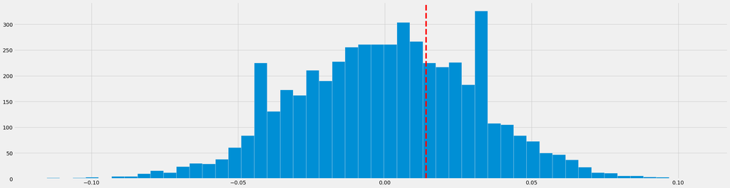

```python
plt.hist(differences2, bins=50)
plt.axvline(x=observed_difference_Lunch, color='r', linestyle='--', label='Observed Difference')
print('Observed Difference:', observed_difference_Lunch)
```

This is what our distribution looks like from the 5000 simulated differences. We can see that the dotted red line on the graph is where our observed value is. Our observed value is towards the middle of the distribution hinting at the fact that our value does not look unusual. To be sure we will view the P-value again to make a conclusion.

```python
empirical_p2 = np.count_nonzero(differences2 <= observed_difference_Lunch) / repetitions
empirical_p2
```

```
0.6954
```

In order for us to reject our null hypothesis we need to have a p-value of less than 0.05, here in this instance of testing we have a p-value of 0.6954. With this p-value we will accept our null hypothesis that there is no correlation between parent's level of education and their child's lunch level.

### **Recap**

In this section we conducted a very similar test to our last hypothesis testing. The major difference here was that we were comparing 2 categorical variables to find correlation. We were still able to apply A/B testing to come to our conclusion. This conclusion was determined by a large p-value, and is the answer to our fourth question: Is a student's lunch level influenced by their parents education level? **No, students are equally likely to receive standard lunch no matter their parent's education level.**

# **Creating a Prediction Model**

This section of the project is going to focus on making a prediction model that can use a students attributes as inputs, and output a predicted average exam score. In this section we will answer both questions five and six.

Our data set is unique in the sense that we have only categorical data as inputs, however some of these categories have more than 2 options. The way that we can get around this is to calculate how each versions of these inputs will effect our students average exam scores. This is called multiple regression, where we find the impact of variables in the form of slopes, and we use those to calculate a predicted exam value. The benefits of this is that our categorical data will be easier to equate to outcomes, and this regression method will give us an actual exam score prediction, rather than a passing/failing classification.

### **Data Preperation**

To start this regression we will establish our data frame and convert all of our values to binary.

```python
students_reg = students[['gender', 'race_ethnicity', 'parental_level_of_education', 'lunch', 'test_preparation_course', 'average']]
students_reg
```

|  | gender | race_ethnicity | parental_level_of_education | lunch | test_preparation_course | average |
| --- | --- | --- | --- | --- | --- | --- |
| 0 | female | group B | bachelor's degree | standard | none | 72.666667 |
| 1 | female | group C | some college | standard | completed | 82.333333 |
| 2 | female | group B | master's degree | standard | none | 92.666667 |
| 3 | male | group A | associate's degree | free/reduced | none | 49.333333 |
| 4 | male | group C | some college | standard | none | 76.333333 |
| ... | ... | ... | ... | ... | ... | ... |
| 995 | female | group E | master's degree | standard | completed | 94.000000 |
| 996 | male | group C | high school | free/reduced | none | 57.333333 |
| 997 | female | group C | high school | free/reduced | completed | 65.000000 |
| 998 | female | group D | some college | standard | completed | 74.333333 |
| 999 | female | group D | some college | free/reduced | none | 83.000000 |

1000 rows × 6 columns

To convert to binary we will use a similar replacement function from before.

```python
students_edit3 = students_reg.copy()

replacements = {
    'some high school': 0,
    'high school': 1,
    'some college': 2,
    "associate's degree": 3,
    "bachelor's degree": 4,
    "master's degree": 5
}

students_edit3['parental_level_of_education'] =students_edit3['parental_level_of_education'].map(replacements).fillna(students_edit3['parental_level_of_education'])

replacements2 = {
    'male': 0,
    'female': 1
}

students_edit3['gender'] =students_edit3['gender'].map(replacements2).fillna(students_edit3['gender'])

replacements3 = {
    'standard': 0,
    'free/reduced': 1
}

students_edit3['lunch'] =students_edit3['lunch'].map(replacements3).fillna(students_edit3['lunch'])

replacements4 = {
    'none': 0,
    'completed': 1
}

students_edit3['test_preparation_course'] =students_edit3['test_preparation_course'].map(replacements4).fillna(students_edit3['test_preparation_course'])

replacements5 = {
    'group A': 0,
    'group B': 1,
    'group C': 2,
    "group D": 3,
    "group E": 4
}

students_edit3['race_ethnicity'] =students_edit3['race_ethnicity'].map(replacements5).fillna(students_edit3['race_ethnicity'])

students_placehold = students_edit3[['gender', 'race_ethnicity', 'parental_level_of_education', 'lunch', 'test_preparation_course', 'average']]
```

```python
students_placehold
```

|  | gender | race_ethnicity | parental_level_of_education | lunch | test_preparation_course | average |
| --- | --- | --- | --- | --- | --- | --- |
| 0 | 1 | 1 | 4 | 0 | 0 | 72.666667 |
| 1 | 1 | 2 | 2 | 0 | 1 | 82.333333 |
| 2 | 1 | 1 | 5 | 0 | 0 | 92.666667 |
| 3 | 0 | 0 | 3 | 1 | 0 | 49.333333 |
| 4 | 0 | 2 | 2 | 0 | 0 | 76.333333 |
| ... | ... | ... | ... | ... | ... | ... |
| 995 | 1 | 4 | 5 | 0 | 1 | 94.000000 |
| 996 | 0 | 2 | 1 | 1 | 0 | 57.333333 |
| 997 | 1 | 2 | 1 | 1 | 1 | 65.000000 |
| 998 | 1 | 3 | 2 | 0 | 1 | 74.333333 |
| 999 | 1 | 3 | 2 | 1 | 0 | 83.000000 |

1000 rows × 6 columns

Here we have our completely converted integer table. We will keep our average as its true value since our output is not a classification. To start our regression we want to split these columns so that they only include binary values of 1 and 0. To do this we will split the race and education columns into columns for each possible entry. We will do this with the code below:

```python
students_placehold['race1'] = np.where(students_placehold['race_ethnicity'] == 1, 1, 0)
students_placehold['race2'] = np.where(students_placehold['race_ethnicity'] == 2, 1, 0)
students_placehold['race3'] = np.where(students_placehold['race_ethnicity'] == 3, 1, 0)
students_placehold['race4'] = np.where(students_placehold['race_ethnicity'] == 4, 1, 0)
students_placehold['education1'] = np.where(students_placehold['parental_level_of_education'] == 1, 1, 0)
students_placehold['education2'] = np.where(students_placehold['parental_level_of_education'] == 2, 1, 0)
students_placehold['education3'] = np.where(students_placehold['parental_level_of_education'] == 3, 1, 0)
students_placehold['education4'] = np.where(students_placehold['parental_level_of_education'] == 4, 1, 0)
students_placehold['education5'] = np.where(students_placehold['parental_level_of_education'] == 5, 1, 0)
```

```python
students_placehold
```

|  | gender | race_ethnicity | parental_level_of_education | lunch | test_preparation_course | average | race1 | race2 | race3 | race4 | education1 | education2 | education3 | education4 | education5 |
| --- | --- | --- | --- | --- | --- | --- | --- | --- | --- | --- | --- | --- | --- | --- | --- |
| 0 | 1 | 1 | 4 | 0 | 0 | 72.666667 | 1 | 0 | 0 | 0 | 0 | 0 | 0 | 1 | 0 |
| 1 | 1 | 2 | 2 | 0 | 1 | 82.333333 | 0 | 1 | 0 | 0 | 0 | 1 | 0 | 0 | 0 |
| 2 | 1 | 1 | 5 | 0 | 0 | 92.666667 | 1 | 0 | 0 | 0 | 0 | 0 | 0 | 0 | 1 |
| 3 | 0 | 0 | 3 | 1 | 0 | 49.333333 | 0 | 0 | 0 | 0 | 0 | 0 | 1 | 0 | 0 |
| 4 | 0 | 2 | 2 | 0 | 0 | 76.333333 | 0 | 1 | 0 | 0 | 0 | 1 | 0 | 0 | 0 |
| ... | ... | ... | ... | ... | ... | ... | ... | ... | ... | ... | ... | ... | ... | ... | ... |
| 995 | 1 | 4 | 5 | 0 | 1 | 94.000000 | 0 | 0 | 0 | 1 | 0 | 0 | 0 | 0 | 1 |
| 996 | 0 | 2 | 1 | 1 | 0 | 57.333333 | 0 | 1 | 0 | 0 | 1 | 0 | 0 | 0 | 0 |
| 997 | 1 | 2 | 1 | 1 | 1 | 65.000000 | 0 | 1 | 0 | 0 | 1 | 0 | 0 | 0 | 0 |
| 998 | 1 | 3 | 2 | 0 | 1 | 74.333333 | 0 | 0 | 1 | 0 | 0 | 1 | 0 | 0 | 0 |
| 999 | 1 | 3 | 2 | 1 | 0 | 83.000000 | 0 | 0 | 1 | 0 | 0 | 1 | 0 | 0 | 0 |

1000 rows × 15 columns

Now that we have the columns split and the values in binary, we will rearrange the table and drop the original columns as we don't need them anymore.

```python
students_binary = students_placehold[['gender', 'race1', 'race2', 'race3', 'race4', 'education1', 'education2', 'education3', 'education4', 'education5', 'lunch', 'test_preparation_course', 'average']]
```

```python
students_binary
```

|  | gender | race1 | race2 | race3 | race4 | education1 | education2 | education3 | education4 | education5 | lunch | test_preparation_course | average |
| --- | --- | --- | --- | --- | --- | --- | --- | --- | --- | --- | --- | --- | --- |
| 0 | 1 | 1 | 0 | 0 | 0 | 0 | 0 | 0 | 1 | 0 | 0 | 0 | 72.666667 |
| 1 | 1 | 0 | 1 | 0 | 0 | 0 | 1 | 0 | 0 | 0 | 0 | 1 | 82.333333 |
| 2 | 1 | 1 | 0 | 0 | 0 | 0 | 0 | 0 | 0 | 1 | 0 | 0 | 92.666667 |
| 3 | 0 | 0 | 0 | 0 | 0 | 0 | 0 | 1 | 0 | 0 | 1 | 0 | 49.333333 |
| 4 | 0 | 0 | 1 | 0 | 0 | 0 | 1 | 0 | 0 | 0 | 0 | 0 | 76.333333 |
| ... | ... | ... | ... | ... | ... | ... | ... | ... | ... | ... | ... | ... | ... |
| 995 | 1 | 0 | 0 | 0 | 1 | 0 | 0 | 0 | 0 | 1 | 0 | 1 | 94.000000 |
| 996 | 0 | 0 | 1 | 0 | 0 | 1 | 0 | 0 | 0 | 0 | 1 | 0 | 57.333333 |
| 997 | 1 | 0 | 1 | 0 | 0 | 1 | 0 | 0 | 0 | 0 | 1 | 1 | 65.000000 |
| 998 | 1 | 0 | 0 | 1 | 0 | 0 | 1 | 0 | 0 | 0 | 0 | 1 | 74.333333 |
| 999 | 1 | 0 | 0 | 1 | 0 | 0 | 1 | 0 | 0 | 0 | 1 | 0 | 83.000000 |

1000 rows × 13 columns

Now you can see that in our new table we don't have columns for every possible entry of the variable. For example race has 5 entries but is only represented with 4 columns. This is because anyone in the group A category will be represented if all 4 race columns have a 0 in them. Meaning that 4 columns represent all 5 of our possible inputs.

### **Multiple Linear Regression**

*With our data sorted and prepped, we can finally start looking at how the variables change the average exam score.*

Multiple regression is just a way of saying that we are finding the slope of every variable, and then looking how they all combine to solve for a predicted exam score. This means we need to find the weight(slope) of all of the variables, then create a long equation that will add all of these together. We will start by splitting our dataset into a training and test set.

```python
train = students_binary.sample(n=500, replace=False)
test = students_binary.drop(train.index)

print(len(train), 'training and', len(test), 'test instances.')
```

```
500 training and 500 test instances.
```

Now to find the slope of these variables first we will generate random slope values and calculate an exam score using those values. Here is an example of us doing that for 1 data point:

```python
def predict(slopes, row):
    return np.dot(slopes, row)

# Assuming test is your DataFrame
example_row = test.drop(columns=['average']).iloc[0]
print('Predicting average exam score for:', example_row)
example_slopes = np.random.normal(10, 1, len(example_row))
print('Using slopes:', example_slopes)
print('Result:', predict(example_slopes, example_row))
```

```
Predicting average exam score for: gender                     1
race1                      1
race2                      0
race3                      0
race4                      0
education1                 0
education2                 0
education3                 0
education4                 1
education5                 0
lunch                      0
test_preparation_course    0
Name: 0, dtype: int64
Using slopes: [ 11.06666574   9.84116006  10.15700738  10.70719664   8.69211783
  10.70564974  11.09898919  10.92866069  10.39560976   9.73272704
   9.82493545   8.48488058]
Result: 31.3034355539
```

This shows the values within the row that we used, the slopes that were generated for the calculation, and the result. Now we can compare this to our actual value for that row using this code:

```python
print('Actual average exam score:', test['average'].iloc[0])
print('Predicted average exam score using random slopes:', predict(example_slopes, example_row))
```

```
Actual average exam score: 72.6666666667
Predicted average exam score using random slopes: 31.3034355539
```

As you can see this is a bit off, to fix this we will perform this prediction on each row of the training set and calculate the root mean squared error. This is the value of the error of this prediction from what the actual score of that data point would be. Then we will find the row that used slopes which produced the smallest error, and those will be our best slopes.

```python
train_average = train['average']
train_attributes = train.drop(columns=['average'])

def rmse(slopes, attributes, average):
    errors = []
    for i in range(len(average)):
        predicted = predict(slopes, attributes.iloc[i])
        actual = average.iloc[i]
        errors.append((predicted - actual) ** 2)
    return np.sqrt(np.mean(errors))

def rmse_train(slopes):
    return rmse(slopes, train_attributes, train_average)

print('RMSE of all training examples using random slopes:', rmse_train(example_slopes))
```

```
RMSE of all training examples using random slopes: 41.3108281273
```

```python
def objective_function(slopes):
    return rmse_train(slopes)

# Perform optimization
best_slopes = minimize(objective_function, x0=example_slopes, method='Nelder-Mead').x

# Print the best slopes for the training set
print('The best slopes for the training set:')
print(train_attributes.columns)
print(best_slopes)

# Calculate and print the RMSE of all training examples using the best slopes
print('RMSE of all training examples using the best slopes:', rmse_train(best_slopes))
```

```
The best slopes for the training set:
Index(['gender', 'race1', 'race2', 'race3', 'race4', 'education1',
       'education2', 'education3', 'education4', 'education5', 'lunch',
       'test_preparation_course'],
      dtype='object')
[  9.04719569  44.70805148  47.10329621  53.26659535  56.43978939
   6.54196059  10.42529373  13.52925274  11.49458705  13.00699441
  -2.85860061  15.07743001]
RMSE of all training examples using the best slopes: 20.5185084114
```

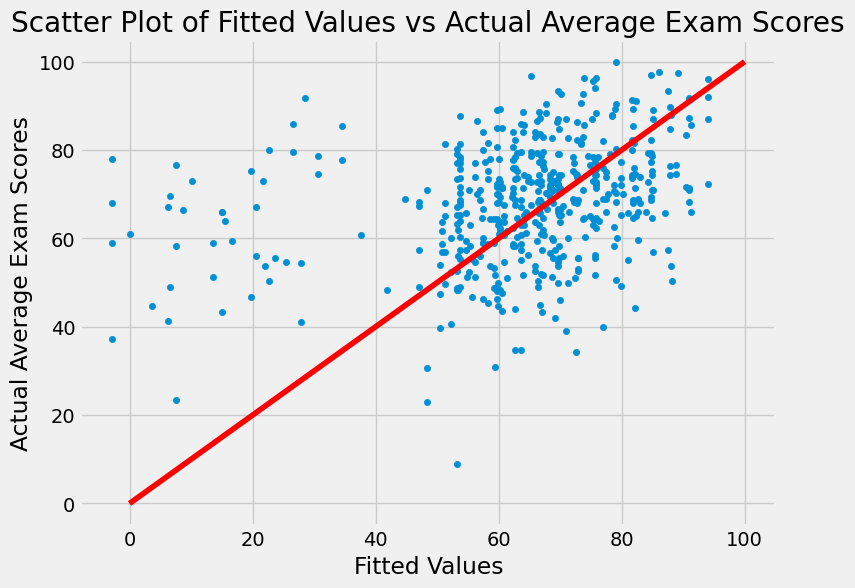

```python
def fit(row):
    return np.dot(best_slopes, row)

fig, ax = plt.subplots(figsize=(8, 6))
test['Fitted'] = test.drop(columns=['average']).apply(fit, axis=1)
test.plot.scatter(x='Fitted', y='average', ax=ax)
plt.plot([0, 100], [0, 100], color='red')
plt.xlabel('Fitted Values')
plt.ylabel('Actual Average Exam Scores')
plt.title('Scatter Plot of Fitted Values vs Actual Average Exam Scores')
plt.show()
```

In this plot we can see that some of the points are falling around the line, meaning our prediction is close to that of the actual average. However, for most of the points we see that our prediction was not very accurate, averaging an error of 20.518 grade points.

### **Recap**

# **Conclusion**

So now we have run multiple tests on our dataset, we have seen all sorts of outcomes, but what have we learned?

From our initial exploration of the data and analysis we learned about the distribution of the data. We discovered what groups within the data are the minority and the majority. We also uncovered that of 1000 data points we only saw 211 unique combinations of traits. All of this initial analysis and discover is very important because it can be used to help explain the outcomes we received from out later testing.

From our second set of A/B testing we revealed that students are equally likely to receive standard lunch no matter their parent's education level. This conclusion found by interpreting our p-value that resulted from a difference of means calculation. This correlation would be more interesting to explore with access to another variable such as parent's income. I say this because it is unlikely that a parent's knowledge will effect their decision on what kind of lunch to get their kid. This decision is more likely to be influenced by a parent's income, and that is something that could possibly be connected to their education level.

We also attempted a multiple regression model to predict the average exam scores of students when provided their attributes. For this model we calculated slopes for each variable, essentially weighing each student's attributes. This model produced an average error of approximately 20.518 grade points. This model struggled from the small size of the data set and the inconsistency of the average exam scores. This model also struggled from the lack of consistency. With only 211 unique inputs and 194 unique outputs it is hard to find a direct relation between input and output. This bring me to my next point:

From all of this testing we saw that although the variables we tested all effect the students average exam scores in some way, they do not determine it. In other words, if a student does test preparations for an exam, it may give that student a better chance of scoring higher, and students who do the preparations may score higher on average. However, that student will not be guaranteed to score higher just for doing test preparations. This inconsistency is driven by the fact that we are looking at human produced data. A student can be given the best possible situation, with every advantage, and they may still fail their exams, because they are still human.